# Abu Dhabi School Bus Project

Hayk Stepanyan

# Part 0: Setup and Introduction

This report analyzes and predicts the probability of a child using the school bus two or more days per week. Thus, the variable is defined as uses_bus and is set to 1 if the parent’s answer in the survey was 2-3 days per week or 4+ days per week and to 0 otherwise.

```r
df <- read_csv("bus_analysis.csv")
df$uses_bus <- factor(df$uses_bus, levels= c(0, 1), labels = c("no", "yes"))

# Use glimpse(df) to find general information about our data.
glimpse(df)
```

```
## Rows: 4,014
## Columns: 96
## $ id.x                <dbl> 119041295094, 119041004711, 119040310131, 11903924…
## $ uses_bus            <fct> yes, yes, yes, yes, no, yes, no, no, no, yes, yes,…
## $ collector           <dbl> 462090491, 462090491, 462090491, 462090491, 462090…
## $ start               <dttm> 2026-01-21 15:37:00, 2026-01-21 06:38:46, 2026-01…
## $ end                 <dttm> 2026-01-21 15:46:30, 2026-01-21 06:50:30, 2026-01…
## $ flag                <dbl> 0, 0, 0, 0, 0, 0, 0, 0, 0, 0, 1, 0, 0, 0, 0, 0, 0,…
## $ lang                <chr> "en", "en", "ar", "en", "ar", "ar", "en", "ar", "a…
## $ role                <dbl> 1, 1, 1, 1, 2, 2, 2, 1, 2, 2, 2, 2, 2, 1, 1, 2, 2,…
## $ n_child_priv        <dbl> 2, 3, 4, 3, 3, 3, 3, 3, 3, 2, 2, 3, 3, 3, 3, 2, 3,…
## $ same_school         <chr> NA, "yes", "yes", "yes", "yes", "yes", "yes", "yes…
## $ child_gender        <dbl> 2, 2, 1, 2, 2, 2, 2, 1, 2, 1, 1, 1, 1, 1, 1, 1, 1,…
## $ child_age           <dbl> 6, 14, 13, 5, 10, 10, 9, 5, 7, 16, 9, 12, 10, 7, 8…
## $ school_city         <dbl> 3, 2, 1, 2, 2, 2, 1, 1, 1, 1, 2, 1, 1, 1, 1, 2, 3,…
```

[output cut: 83 more lines]

# Part 1: Exploratory Data Analysis

Before we build any models, we explore the dataset to understand patterns. Using glimpse(df), we find that the dataset contains 4014 rows and 96 columns.

Many of these variables were collected for administrative or different purposes and are not directly correlated with our target variable. One of the most important steps in data analysis is choosing the correct variables that have an impact on our studies. Therefore, multiple columns are not going to be used, such as collector, survey timestamps, elec_car and others.

Hence, we focus on variables that are more likely to be associated with bus usage. For example the driving distance from home to school is expected to be a major predictor.

## Target Variable Balance check

```r
target_counts <- count(df, uses_bus)
target_counts$pct <- target_counts$n / sum(target_counts$n)
kable(
  target_counts,
  col.names = c("Uses Bus Frequently", "Count", "Proportion"),
  digits = 3,
  caption = "Distribution of the target variable uses_bus"
)
```

Distribution of the target variable uses_bus

| Uses Bus Frequently | Count | Proportion |
| --- | --- | --- |
| no | 1625 | 0.405 |
| yes | 2389 | 0.595 |

We do this step in order to see if there is a big imbalance in our target variable. If 95% of uses_bus was 1, the model might always predict “yes” and still be 95% accurate, without learning, which could result in completely wrong answers in the test dataset.

It is beneficial for us that the proportions are roughly 60% / 40% as we do not have to use any special balancing techniques and can move forward.

## Univariate Analysis

### Plot 1: Distribution of Driving Distance from Home to School

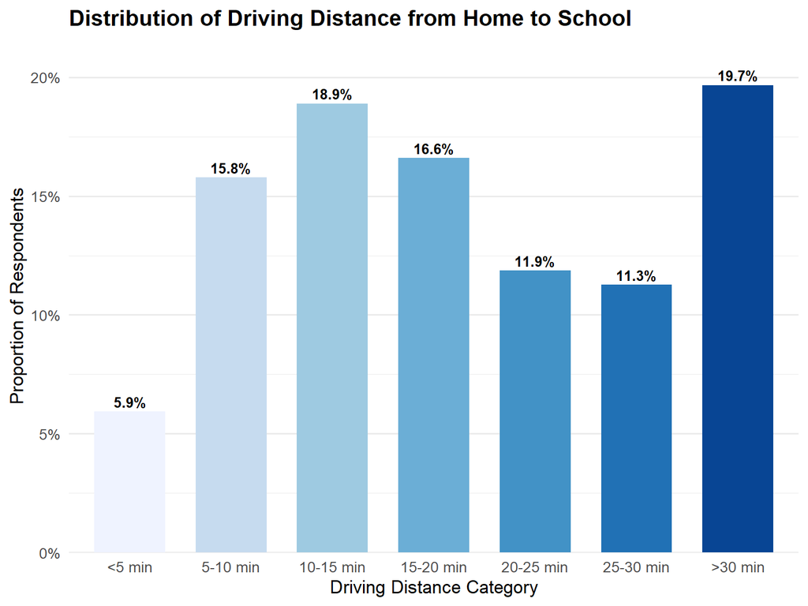

```r
dist_data <- filter(df, !is.na(dist_home_school))
dist_data$dist_home_school <- factor(dist_data$dist_home_school)
dist_counts <- count(dist_data, dist_home_school)
dist_counts$pct <- dist_counts$n / sum(dist_counts$n)

distance_labels <- c(
  "1" = "<5 min",
  "2" = "5-10 min",
  "3" = "10-15 min",
  "4" = "15-20 min",
  "5" = "20-25 min",
  "6" = "25-30 min",
  "7" = ">30 min"
)

plot1 <- ggplot(dist_counts, aes(x = dist_home_school, y = pct, fill = dist_home_school))
plot1 <- plot1 + geom_col(width = 0.7, show.legend = FALSE)
plot1 <- plot1 + geom_text(
  aes(label = percent(pct, accuracy = 0.1)),
  vjust = -0.4,
  size = 3.5,
  fontface = "bold"
)
plot1 <- plot1 + scale_x_discrete(labels = distance_labels)
plot1 <- plot1 + scale_y_continuous(
  labels = percent_format(),
  expand = expansion(mult = c(0, 0.1))
)
plot1 <- plot1 + scale_fill_brewer(palette = "Blues")
plot1 <- plot1 + labs(
  title = "Distribution of Driving Distance from Home to School",
  x = "Driving Distance Category",
  y = "Proportion of Respondents"
)
plot1 <- plot1 + theme_minimal(base_size = 13)
plot1 <- plot1 + theme(
  plot.title = element_text(face = "bold"),
  plot.subtitle = element_text(color = "grey50"),
  panel.grid.major.x = element_blank()
)

print(plot1)
```

### Plot 2: Distribution of Curriculum Type

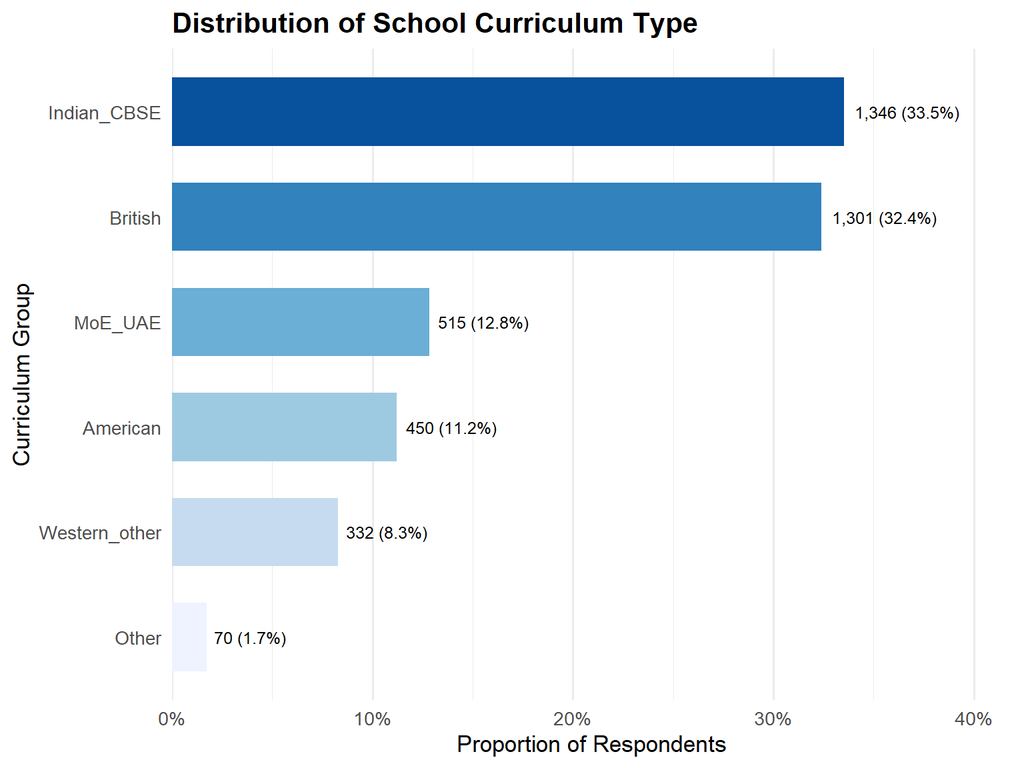

```r
curr_data <- filter(df, !is.na(curriculum_grp))
curr_counts <- count(curr_data, curriculum_grp)
curr_counts$pct <- curr_counts$n / sum(curr_counts$n)
curr_counts$curriculum_grp <- reorder(curr_counts$curriculum_grp, curr_counts$n)


plot2 <- ggplot(curr_counts, aes(x = curriculum_grp, y = pct, fill = curriculum_grp))
plot2 <- plot2 + geom_col(width = 0.65, show.legend = FALSE)
plot2 <- plot2 + geom_text(
  aes(label = paste0(comma(n), " (", percent(pct, accuracy = 0.1), ")")),
  hjust = -0.1,
  size = 3.3
)

plot2 <- plot2 + scale_y_continuous(
  labels = percent_format(),
  expand = expansion(mult = c(0, 0.25))
)
plot2 <- plot2 + scale_fill_brewer(palette = "Blues")
plot2 <- plot2 + coord_flip()
plot2 <- plot2 + labs(
  title = "Distribution of School Curriculum Type",
  x = "Curriculum Group",
  y = "Proportion of Respondents"
)

plot2 <- plot2 + theme_minimal(base_size = 13)
plot2 <- plot2 + theme(
  plot.title = element_text(face = "bold"),
  plot.subtitle = element_text(color = "grey50"),
  panel.grid.major.y = element_blank()
)
print(plot2)
```

## Bivariate Analysis

### Plot 3: Bus Usage Rate by Driving Distance

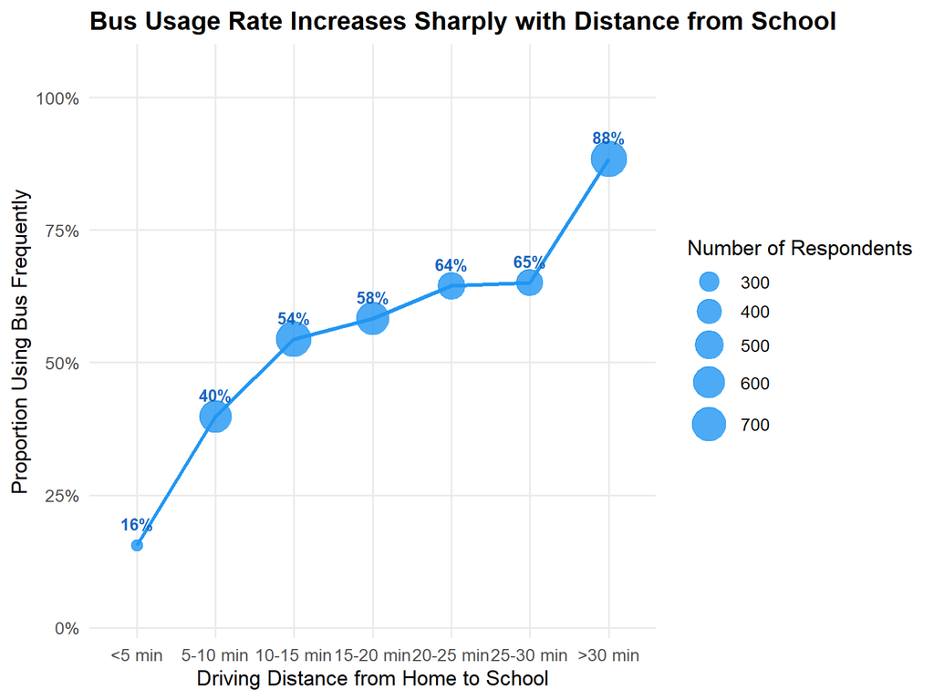

```r
dist_bus_data <- filter(df, !is.na(dist_home_school))
dist_bus_data$dist_home_school <- factor(dist_bus_data$dist_home_school)
distance_categories <- unique(dist_bus_data$dist_home_school)
pct_bus_values <- tapply(dist_bus_data$uses_bus == "yes", dist_bus_data$dist_home_school, mean)
n_values <- tapply(dist_bus_data$uses_bus, dist_bus_data$dist_home_school, length)
dist_bus_summary <- data.frame(
  dist_home_school = names(pct_bus_values),
  pct_bus = as.numeric(pct_bus_values),
  n = as.numeric(n_values)
)
dist_bus_summary$dist_home_school <- factor(dist_bus_summary$dist_home_school)


plot3 <- ggplot(dist_bus_summary, aes(x = dist_home_school, y = pct_bus, group = 1))
plot3 <- plot3 + geom_line(color = "#2196F3", linewidth = 1.2)
plot3 <- plot3 + geom_point(aes(size = n), color = "#2196F3", alpha = 0.8)
plot3 <- plot3 + geom_text(
  aes(label = percent(pct_bus, accuracy = 1)),
  vjust = -1.2,
  size = 3.5,
  fontface = "bold",
  color = "#1565C0"
)
plot3 <- plot3 + scale_x_discrete(labels = distance_labels)
plot3 <- plot3 + scale_y_continuous(
  labels = percent_format(),
  limits = c(0, 1),
  expand = expansion(mult = c(0.02, 0.1))
)
plot3 <- plot3 + scale_size_continuous(name = "Number of Respondents", range = c(3, 10))
plot3 <- plot3 + labs(
  title = "Bus Usage Rate Increases Sharply with Distance from School",
  x = "Driving Distance from Home to School",
  y = "Proportion Using Bus Frequently"
)
plot3 <- plot3 + theme_minimal(base_size = 13)
plot3 <- plot3 + theme(
  plot.title = element_text(face = "bold"),
  plot.subtitle = element_text(color = "grey50"),
  panel.grid.minor = element_blank()
)
print(plot3)
```

**Interpretation:** The relationship between distance and bus usage is very clear. At less than 5 minutes from school, only few families use the bus frequently. On the other hand, almost 90% of families living more than 30 minutes away use prefer to use the bus frequently.

### Plot 4: Bus Usage Rate by Curriculum Type and Number of Cars

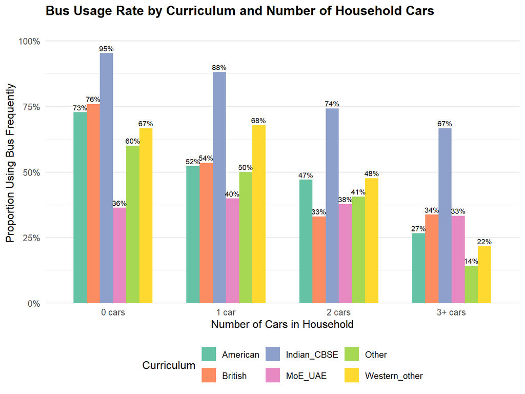

```r
curr_cars_data <- filter(df, !is.na(curriculum_grp), !is.na(n_cars))
# In the survey: 1 = 0 cars, 2 = 1 car, 3 = 2 cars, 4 = 3+ cars
curr_cars_data$n_cars_label <- case_when(
  curr_cars_data$n_cars == 1 ~ "0 cars",
  curr_cars_data$n_cars == 2 ~ "1 car",
  curr_cars_data$n_cars == 3 ~ "2 cars",
  curr_cars_data$n_cars == 4 ~ "3+ cars"
)
curr_cars_data$n_cars_label <- factor(
  curr_cars_data$n_cars_label,
  levels = c("0 cars", "1 car", "2 cars", "3+ cars")
)
pct_bus_grouped <- tapply(
  curr_cars_data$uses_bus == "yes",
  interaction(curr_cars_data$curriculum_grp, curr_cars_data$n_cars_label),
  mean
)
n_grouped <- tapply(
  curr_cars_data$uses_bus,
  interaction(curr_cars_data$curriculum_grp, curr_cars_data$n_cars_label),
  length
)
curr_cars_summary <- data.frame(
  group = names(pct_bus_grouped),
  pct_bus = as.numeric(pct_bus_grouped),
  n = as.numeric(n_grouped)
)
curr_cars_summary$curriculum_grp <- sapply(
  strsplit(curr_cars_summary$group, "\\."),
  function(x) x[1]
)
curr_cars_summary$n_cars_label <- sapply(
  strsplit(curr_cars_summary$group, "\\."),
  function(x) x[2]
)
curr_cars_summary$n_cars_label <- factor(
  curr_cars_summary$n_cars_label,
  levels = c("0 cars", "1 car", "2 cars", "3+ cars")
)
plot4 <- ggplot(
  curr_cars_summary,
  aes(x = n_cars_label, y = pct_bus, fill = curriculum_grp)
)
plot4 <- plot4 + geom_col(position = "dodge", width = 0.7)
plot4 <- plot4 + geom_text(
  aes(label = percent(pct_bus, accuracy = 1)),
  position = position_dodge(width = 0.7),
  vjust = -0.4,
  size = 2.8
)
plot4 <- plot4 + scale_y_continuous(
  labels = percent_format(),
  expand = expansion(mult = c(0, 0.12))
)
plot4 <- plot4 + scale_fill_brewer(palette = "Set2", name = "Curriculum")
plot4 <- plot4 + labs(
  title = "Bus Usage Rate by Curriculum and Number of Household Cars",
  x = "Number of Cars in Household",
  y = "Proportion Using Bus Frequently"
)
plot4 <- plot4 + theme_minimal(base_size = 12)
plot4 <- plot4 + theme(
  plot.title = element_text(face = "bold"),
  plot.subtitle = element_text(color = "grey50"),
  legend.position = "bottom",
  panel.grid.major.x = element_blank()
)

print(plot4)
```

## Missing Data Analysis

```r
vars_of_interest <- c(
  "dist_home_school", "n_cars", "income_imp_num", "curriculum_grp",
  "mother_license", "father_license", "neigh_group", "child_age",
  "bus_stop", "bus_rely", "hous_type", "car_cost", "car_time", "bus_cost",
  "father_job", "mother_job"
)
selected_cols <- df[, vars_of_interest]
missing_counts <- colSums(is.na(selected_cols))
missing_pct <- missing_counts / nrow(df)
missing_table <- data.frame(
  Variable = names(missing_counts),
  Missing_Count = as.integer(missing_counts),
  Missing_Pct = missing_pct
)
missing_table <- missing_table[order(-missing_table$Missing_Count), ]
kable(
  missing_table,
  row.names = FALSE,
  digits = 3,
  col.names = c("Variable", "Missing Count", "Missing %")
)
```

| Variable | Missing Count | Missing % |
| --- | --- | --- |
| father_job | 183 | 0.046 |
| father_license | 160 | 0.040 |
| child_age | 157 | 0.039 |
| car_cost | 151 | 0.038 |
| car_time | 151 | 0.038 |
| mother_job | 76 | 0.019 |
| bus_rely | 66 | 0.016 |
| bus_cost | 58 | 0.014 |
| bus_stop | 57 | 0.014 |
| mother_license | 39 | 0.010 |
| hous_type | 25 | 0.006 |
| n_cars | 13 | 0.003 |
| dist_home_school | 2 | 0.000 |
| income_imp_num | 0 | 0.000 |
| curriculum_grp | 0 | 0.000 |
| neigh_group | 0 | 0.000 |

**Imputation strategy:** Rather than dropping incomplete rows (which would reduce sample size and risk biasing results toward fully-responding families), we impute every predictor we plan to use:

- **Numeric variables** (`child_age`, `bus_stop`, `bus_rely`, `car_cost`, `car_time`, `bus_cost`, `income_imp_num`): impute with the **median**. The median is robust to outliers and preserves the central tendency of the variable.
- **Categorical variables** (`dist_home_school`, `n_cars`, `mother_license`, `father_license`, `hous_type`, `father_job`, `mother_job`): impute with the **mode** (most frequent category). This keeps the variable on its original scale without inventing a new “Unknown” level that would have no real-world meaning to the model.

# Part 2: Basic Logistic Regression Model

## Data Preparation

We impute missing values (rather than calling `na.omit()`, which would drop ~10% of the data and risk introducing selection bias) and convert all categorical predictors into factors so the models treat them correctly.

```r
model_data <- df[, c(
  "uses_bus", "dist_home_school", "n_cars", "curriculum_grp",
  "mother_license", "income_imp_num", "hous_type", "child_age",
  "neigh_group", "bus_stop", "bus_rely", "father_license", "car_cost",
  "car_time", "bus_cost", "father_job", "mother_job"
)]

# --- Numeric imputation with the median ---
num_vars <- c("child_age", "bus_stop", "bus_rely", "car_cost", "car_time", "bus_cost", "income_imp_num")
for (v in num_vars) {
  med <- median(model_data[[v]], na.rm = TRUE)
  model_data[[v]] <- ifelse(is.na(model_data[[v]]), med, model_data[[v]])
}

# --- Categorical imputation with the mode, then factor conversion ---
cat_vars <- c("dist_home_school", "n_cars", "mother_license", "father_license",
              "hous_type", "father_job", "mother_job", "curriculum_grp", "neigh_group")

get_mode <- function(x) {
  ux <- unique(x[!is.na(x)])
  ux[which.max(tabulate(match(x, ux)))]
}

for (v in cat_vars) {
  m <- get_mode(model_data[[v]])
  model_data[[v]][is.na(model_data[[v]])] <- m
  model_data[[v]] <- factor(model_data[[v]])
}

cat("Rows after imputation:", nrow(model_data), "\n")
```

```
## Rows after imputation: 4014
```

```r
cat("Total NAs left:", sum(is.na(model_data)), "\n")
```

```
## Total NAs left: 0
```

```r
print(table(model_data$uses_bus))
```

```
##
##   no  yes
## 1625 2389
```

## Train / Test Split

To honestly compare the two models, we split the data into 80% training and 20% test before fitting anything. Both models are fit only on the training set and evaluated only on the held-out test set, so the accuracies we report are estimates of how the model would perform on new, unseen families. We stratify the split by `uses_bus` so that the train and test sets have the same class balance as the full data.

```r
set.seed(06052005)
split <- initial_split(model_data, prop = 0.8, strata = uses_bus)
train_data <- training(split)
test_data  <- testing(split)

cat("Train rows:", nrow(train_data), "\n")
```

```
## Train rows: 3211
```

```r
cat("Test rows: ", nrow(test_data), "\n")
```

```
## Test rows:  803
```

```r
cat("Train class balance:\n"); print(prop.table(table(train_data$uses_bus)))
```

```
## Train class balance:
```

```
##
##        no       yes
## 0.4048583 0.5951417
```

```r
cat("Test class balance:\n");  print(prop.table(table(test_data$uses_bus)))
```

```
## Test class balance:
```

```
##
##        no       yes
## 0.4047323 0.5952677
```

## Fit the Logistic Regression Model

```r
logit_model <- glm(
  uses_bus ~ dist_home_school + n_cars + curriculum_grp + mother_license + income_imp_num + hous_type + dist_home_school:n_cars,
  data = train_data,
  family = binomial(link = "logit")
)
summary(logit_model)
```

```
##
## Call:
## glm(formula = uses_bus ~ dist_home_school + n_cars + curriculum_grp +
##     mother_license + income_imp_num + hous_type + dist_home_school:n_cars,
##     family = binomial(link = "logit"), data = train_data)
##
## Coefficients:
##                             Estimate Std. Error z value Pr(>|z|)
## (Intercept)                 -1.93407    0.62111  -3.114 0.001846 **
## dist_home_school2            2.20994    0.67943   3.253 0.001143 **
## dist_home_school3            1.85207    0.70967   2.610 0.009061 **
## dist_home_school4            3.14466    0.78803   3.991 6.59e-05 ***
## dist_home_school5            2.98005    0.83818   3.555 0.000377 ***
## dist_home_school6            2.74562    0.82831   3.315 0.000917 ***
## dist_home_school7            3.68772    0.79773   4.623 3.79e-06 ***
## n_cars2                     -0.46532    0.65548  -0.710 0.477771
## n_cars3                     -0.83149    0.74167  -1.121 0.262244
## n_cars4                     -0.32991    0.97551  -0.338 0.735222
## curriculum_grpBritish       -0.26882    0.13804  -1.947 0.051482 .
## curriculum_grpIndian_CBSE    1.37706    0.16047   8.581  < 2e-16 ***
## curriculum_grpMoE_UAE       -0.60329    0.16966  -3.556 0.000377 ***
## curriculum_grpOther          0.23681    0.32995   0.718 0.472925
## curriculum_grpWestern_other  0.15025    0.18208   0.825 0.409285
## mother_license2              0.44192    0.12567   3.517 0.000437 ***
## mother_license3              0.27584    0.13306   2.073 0.038165 *
## income_imp_num               0.04002    0.02983   1.342 0.179728
## hous_type2                   0.09848    0.25800   0.382 0.702669
## hous_type3                   0.43916    0.09881   4.444 8.81e-06 ***
## hous_type4                  -0.85315    0.25212  -3.384 0.000715 ***
## dist_home_school2:n_cars2   -0.70398    0.74846  -0.941 0.346927
## dist_home_school3:n_cars2    0.18206    0.77456   0.235 0.814168
## dist_home_school4:n_cars2   -0.85301    0.84744  -1.007 0.314141
## dist_home_school5:n_cars2   -0.07731    0.90158  -0.086 0.931669
## dist_home_school6:n_cars2   -0.01676    0.89251  -0.019 0.985015
## dist_home_school7:n_cars2   -0.04425    0.86797  -0.051 0.959344
## dist_home_school2:n_cars3   -0.79387    0.82771  -0.959 0.337497
## dist_home_school3:n_cars3    0.33423    0.84786   0.394 0.693431
## dist_home_school4:n_cars3   -0.96443    0.91655  -1.052 0.292690
## dist_home_school5:n_cars3   -0.55045    0.96626  -0.570 0.568902
## dist_home_school6:n_cars3   -0.55673    0.96163  -0.579 0.562625
## dist_home_school7:n_cars3   -0.43973    0.94328  -0.466 0.641095
## dist_home_school2:n_cars4   -1.88986    1.12384  -1.682 0.092644 .
## dist_home_school3:n_cars4   -0.25760    1.10063  -0.234 0.814949
## dist_home_school4:n_cars4   -1.76507    1.16045  -1.521 0.128256
## dist_home_school5:n_cars4   -2.38111    1.20601  -1.974 0.048338 *
## dist_home_school6:n_cars4   -1.41452    1.20504  -1.174 0.240460
## dist_home_school7:n_cars4   -1.85205    1.19665  -1.548 0.121696
## ---
## Signif. codes:  0 '***' 0.001 '**' 0.01 '*' 0.05 '.' 0.1 ' ' 1
##
## (Dispersion parameter for binomial family taken to be 1)
##
##     Null deviance: 4334.4  on 3210  degrees of freedom
## Residual deviance: 3266.5  on 3172  degrees of freedom
## AIC: 3344.5
##
## Number of Fisher Scoring iterations: 5
```

## Model Summary Interpretation

```r
odds_ratios <- exp(coef(logit_model))
conf_int <- exp(confint(logit_model))
p_values <- summary(logit_model)$coefficients[, 4]
results_table <- data.frame(
  Term = names(odds_ratios),
  OddsRatio = round(odds_ratios, 3),
  CI_low = round(conf_int[, 1], 3),
  CI_high = round(conf_int[, 2], 3),
  pvalue = round(p_values, 4),
  Significant = ifelse(p_values < 0.05, "Yes", "No")
)
results_table <- results_table[order(results_table$pvalue), ]
kable(
  results_table,
  row.names = FALSE,
)
```

| Term | OddsRatio | CI_low | CI_high | pvalue | Significant |
| --- | --- | --- | --- | --- | --- |
| dist_home_school7 | 39.953 | 9.060 | 214.683 | 0.0000 | Yes |
| curriculum_grpIndian_CBSE | 3.963 | 2.898 | 5.437 | 0.0000 | Yes |
| hous_type3 | 1.551 | 1.279 | 1.884 | 0.0000 | Yes |
| dist_home_school4 | 23.212 | 5.278 | 119.310 | 0.0001 | Yes |
| dist_home_school5 | 19.689 | 4.103 | 113.540 | 0.0004 | Yes |
| curriculum_grpMoE_UAE | 0.547 | 0.392 | 0.762 | 0.0004 | Yes |
| mother_license2 | 1.556 | 1.217 | 1.992 | 0.0004 | Yes |
| hous_type4 | 0.426 | 0.258 | 0.696 | 0.0007 | Yes |
| dist_home_school6 | 15.574 | 3.299 | 87.981 | 0.0009 | Yes |
| dist_home_school2 | 9.115 | 2.500 | 36.957 | 0.0011 | Yes |
| (Intercept) | 0.145 | 0.040 | 0.470 | 0.0018 | Yes |
| dist_home_school3 | 6.373 | 1.647 | 27.338 | 0.0091 | Yes |
| mother_license3 | 1.318 | 1.016 | 1.712 | 0.0382 | Yes |
| dist_home_school5:n_cars4 | 0.092 | 0.009 | 1.116 | 0.0483 | Yes |
| curriculum_grpBritish | 0.764 | 0.583 | 1.002 | 0.0515 | No |
| dist_home_school2:n_cars4 | 0.151 | 0.018 | 1.613 | 0.0926 | No |
| dist_home_school7:n_cars4 | 0.157 | 0.015 | 1.875 | 0.1217 | No |
| dist_home_school4:n_cars4 | 0.171 | 0.018 | 1.933 | 0.1283 | No |
| income_imp_num | 1.041 | 0.982 | 1.104 | 0.1797 | No |
| dist_home_school6:n_cars4 | 0.243 | 0.023 | 2.939 | 0.2405 | No |
| n_cars3 | 0.435 | 0.100 | 1.917 | 0.2622 | No |
| dist_home_school4:n_cars3 | 0.381 | 0.060 | 2.254 | 0.2927 | No |
| dist_home_school4:n_cars2 | 0.426 | 0.075 | 2.133 | 0.3141 | No |
| dist_home_school2:n_cars3 | 0.452 | 0.087 | 2.304 | 0.3375 | No |
| dist_home_school2:n_cars2 | 0.495 | 0.108 | 2.088 | 0.3469 | No |
| curriculum_grpWestern_other | 1.162 | 0.814 | 1.662 | 0.4093 | No |
| curriculum_grpOther | 1.267 | 0.662 | 2.422 | 0.4729 | No |
| n_cars2 | 0.628 | 0.178 | 2.415 | 0.4778 | No |
| dist_home_school6:n_cars3 | 0.573 | 0.081 | 3.669 | 0.5626 | No |
| dist_home_school5:n_cars3 | 0.577 | 0.081 | 3.715 | 0.5689 | No |
| dist_home_school7:n_cars3 | 0.644 | 0.095 | 3.974 | 0.6411 | No |
| dist_home_school3:n_cars3 | 1.397 | 0.258 | 7.393 | 0.6934 | No |
| hous_type2 | 1.103 | 0.664 | 1.828 | 0.7027 | No |
| n_cars4 | 0.719 | 0.084 | 4.464 | 0.7352 | No |
| dist_home_school3:n_cars2 | 1.200 | 0.250 | 5.330 | 0.8142 | No |
| dist_home_school3:n_cars4 | 0.773 | 0.095 | 8.006 | 0.8149 | No |
| dist_home_school5:n_cars2 | 0.926 | 0.144 | 5.104 | 0.9317 | No |
| dist_home_school7:n_cars2 | 0.957 | 0.158 | 4.927 | 0.9593 | No |
| dist_home_school6:n_cars2 | 0.983 | 0.156 | 5.340 | 0.9850 | No |

**Interpretation of key results:**

The logistic regression models the **log-odds** of `uses_bus = yes`. After applying the exponential function, we get odds ratios. An odds ratio > 1 means the predictor increases the odds of frequent bus use while < 1 means it decreases them.

**Two statistically significant predictors:**

1. **`dist_home_school7` (> 30 min driving distance):** This has the largest positive coefficient in the model. Meaning a family living more than 30 minutes from school has much higher odds of the child using the bus frequently compared to a family living less than 5 minutes away. This makes perfect sense as a 30-minute daily drive each way adds up to 2 hours.
2. **`curriculum_grpIndian_CBSE`:** Holding all other variables constant, children attending Indian CBSE schools have much higher odds of frequent bus use compared to American curriculum schools (the reference level in R is alphabetical). This reflects both the geographic placement of Indian schools and strong cultural community standards around organized school transport in Indian households.

## Confusion Matrix and Accuracy (on the held-out test set)

```r
logit_probs <- predict(logit_model, newdata = test_data, type = "response")
logit_pred <- ifelse(logit_probs >= 0.5, "yes", "no")
logit_pred <- factor(logit_pred, levels = c("no", "yes"))
cm_logit <- confusionMatrix(logit_pred, test_data$uses_bus, positive = "yes")
print(cm_logit)
```

```
## Confusion Matrix and Statistics
##
##           Reference
## Prediction  no yes
##        no  215 109
##        yes 110 369
##
##                Accuracy : 0.7273
##                  95% CI : (0.695, 0.7578)
##     No Information Rate : 0.5953
##     P-Value [Acc > NIR] : 3.882e-15
##
##                   Kappa : 0.4337
##
##  Mcnemar's Test P-Value : 1
##
##             Sensitivity : 0.7720
##             Specificity : 0.6615
##          Pos Pred Value : 0.7704
##          Neg Pred Value : 0.6636
##              Prevalence : 0.5953
##          Detection Rate : 0.4595
##    Detection Prevalence : 0.5965
##       Balanced Accuracy : 0.7168
##
##        'Positive' Class : yes
##
```

```r
metrics_table <- data.frame(
  Metric = c("Accuracy", "Sensitivity", "Specificity", "Precision", "Kappa"),
  Value = c(
    cm_logit$overall["Accuracy"],
    cm_logit$byClass["Sensitivity"],
    cm_logit$byClass["Specificity"],
    cm_logit$byClass["Precision"],
    cm_logit$overall["Kappa"]
  )
)
metrics_table$Value <- round(metrics_table$Value, 3)
kable(metrics_table, row.names = FALSE)
```

| Metric | Value |
| --- | --- |
| Accuracy | 0.727 |
| Sensitivity | 0.772 |
| Specificity | 0.662 |
| Precision | 0.770 |
| Kappa | 0.434 |

**Interpretation:** From the confusion matrix we can interpret how well the model performed on data it has never seen before. The accuracy is reasonable, but logistic regression assumes linearity in the log-odds and cannot capture more complex patterns. We aim to beat it in Part 3.

# Part 3: Random Forest Model

## Why Random Forest?

Logistic regression is a strong model, but it makes restrictive assumptions. It assumes a linear relationship between predictors and the log-odds of the outcome, and cannot automatically capture interactions or non-linear patterns.

A **Random Forest** works differently. It builds many decision trees, each trained on a random subset of the data and a random subset of predictors. The final prediction is the average probability across all trees. This approach:

- **Handles non-linear relationships** automatically (distance may have a threshold effect, not a smooth linear one)
- **Captures interactions** between variables (e.g., Indian curriculum × far distance)
- **Is robust to outliers and missing patterns** because outliers usually end up in a leaf away from the main data and do not affect the decisions that much.
- **Gives variable importance scores** that tell us which predictors matter most
- **Almost always outperforms logistic regression** on real-world data

## Fit the Random Forest

Note that all categorical predictors — including `father_job` and `mother_job`, which are stored as numeric codes in the raw data — were converted to factors in the data preparation step above. This is essential: without factoring, the Random Forest would treat them as continuous variables and search for numeric split points like `father_job < 2.5`, which is meaningless for unordered job categories.

```r
set.seed(06052005)
rf_model <- randomForest(
  uses_bus ~ dist_home_school + n_cars + curriculum_grp + mother_license + income_imp_num + hous_type + child_age + neigh_group + bus_stop + bus_rely + father_license + car_cost + car_time + bus_cost + father_job + mother_job,
  data = train_data,
  ntree = 500,
  mtry = 4,
  importance = TRUE,
  keep.forest = TRUE
)
print(rf_model)
```

```
##
## Call:
##  randomForest(formula = uses_bus ~ dist_home_school + n_cars +      curriculum_grp + mother_license + income_imp_num + hous_type +      child_age + neigh_group + bus_stop + bus_rely + father_license +      car_cost + car_time + bus_cost + father_job + mother_job,      data = train_data, ntree = 5…
##                Type of random forest: classification
##                      Number of trees: 500
## No. of variables tried at each split: 4
##
##         OOB estimate of  error rate: 14.86%
## Confusion matrix:
##      no  yes class.error
## no  992  308  0.23692308
## yes 169 1742  0.08843537
```

## Variable Importance

```r
importance_raw <- importance(rf_model)
importance_df <- data.frame(
  Variable = rownames(importance_raw),
  MeanDecreaseAccuracy = importance_raw[, "MeanDecreaseAccuracy"],
  MeanDecreaseGini = importance_raw[, "MeanDecreaseGini"]
)
importance_df <- importance_df[order(-importance_df$MeanDecreaseAccuracy), ]

kable(
  importance_df,
  row.names = FALSE,
  digits = 3,
)
```

| Variable | MeanDecreaseAccuracy | MeanDecreaseGini |
| --- | --- | --- |
| bus_stop | 49.108 | 273.913 |
| bus_rely | 46.624 | 255.713 |
| dist_home_school | 41.681 | 133.899 |
| curriculum_grp | 37.807 | 132.720 |
| bus_cost | 32.299 | 138.136 |
| neigh_group | 25.591 | 103.398 |
| car_time | 22.474 | 66.946 |
| car_cost | 19.812 | 62.031 |
| father_job | 18.294 | 33.547 |
| n_cars | 18.016 | 56.177 |
| mother_license | 13.266 | 33.200 |
| income_imp_num | 12.635 | 58.581 |
| hous_type | 12.507 | 39.564 |
| child_age | 5.302 | 88.345 |
| mother_job | 4.279 | 50.508 |
| father_license | 1.994 | 7.486 |

As mentioned before using the random forest has multiple advantages. One of which is the ability to identify the importance of a variable. We do this by using **MeanDecreaseAccuracy** which works the following way. It takes the variable and shuffles its values across all the rows without changing anything else in the data. Which means that after doing the same operations we will be able to see a difference in accuracy, as if living more than 30 minutes away gets replaced by living only 5 minutes away the prediction is going to lean towards not using the bus instead of using it. Hence the more it affects the accuracy the more important the variable was. The higher the score the more important the variable is.

Another variable on the table is **MeanDecreaseGini**, it measures how much each variable reduces the Giny impurity across all splits of trees. Giny purity is how strong the decision is in the tree between two choices. Pure means one choice is mostly a “yes” prediction and the other is mostly a “no” prediction. For example dist_home_school variable, when considering families living 5 minutes away and more than 30 minutes away the two groups are very pure, as one of the groups mostly uses buses, and the other does not. The higher the score the more pure the split is.

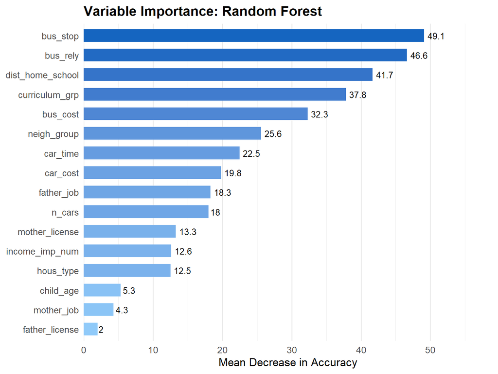

```r
importance_df$Variable <- reorder(importance_df$Variable, importance_df$MeanDecreaseAccuracy)
imp_plot <- ggplot(
  importance_df,
  aes(x = Variable, y = MeanDecreaseAccuracy, fill = MeanDecreaseAccuracy)
)
imp_plot <- imp_plot + geom_col(width = 0.65, show.legend = FALSE)
imp_plot <- imp_plot + geom_text(
  aes(label = round(MeanDecreaseAccuracy, 1)),
  hjust = -0.2,
  size = 3.5
)
imp_plot <- imp_plot + scale_fill_gradient(low = "#90CAF9", high = "#1565C0")
imp_plot <- imp_plot + scale_y_continuous(expand = expansion(mult = c(0, 0.2)))
imp_plot <- imp_plot + coord_flip()
imp_plot <- imp_plot + labs(
  title = "Variable Importance: Random Forest",
  x = NULL,
  y = "Mean Decrease in Accuracy",
)
imp_plot <- imp_plot + theme_minimal(base_size = 13)
imp_plot <- imp_plot + theme(
  plot.title = element_text(face = "bold"),
  plot.subtitle = element_text(color = "grey50"),
  panel.grid.major.y = element_blank()
)
print(imp_plot)
```

## Random Forest Performance (on the held-out test set)

```r
rf_pred <- predict(rf_model, newdata = test_data, type = "response")
rf_probs <- predict(rf_model, newdata = test_data, type = "prob")[, "yes"]
cm_rf <- confusionMatrix(rf_pred, test_data$uses_bus, positive = "yes")
print(cm_rf)
```

```
## Confusion Matrix and Statistics
##
##           Reference
## Prediction  no yes
##        no  250  47
##        yes  75 431
##
##                Accuracy : 0.8481
##                  95% CI : (0.8213, 0.8722)
##     No Information Rate : 0.5953
##     P-Value [Acc > NIR] : < 2e-16
##
##                   Kappa : 0.6803
##
##  Mcnemar's Test P-Value : 0.01451
##
##             Sensitivity : 0.9017
##             Specificity : 0.7692
##          Pos Pred Value : 0.8518
##          Neg Pred Value : 0.8418
##              Prevalence : 0.5953
##          Detection Rate : 0.5367
##    Detection Prevalence : 0.6301
##       Balanced Accuracy : 0.8355
##
##        'Positive' Class : yes
##
```

## Model Comparison

Both models are evaluated on the same 20% held-out test set, so this comparison is fair and reflects expected real-world performance on new families.

```r
comparison_table <- data.frame(
  Model = c("Logistic Regression", "Random Forest"),
  Accuracy = round(c(cm_logit$overall["Accuracy"],  cm_rf$overall["Accuracy"]),  3),
  Sensitivity = round(c(cm_logit$byClass["Sensitivity"], cm_rf$byClass["Sensitivity"]), 3),
  Specificity = round(c(cm_logit$byClass["Specificity"], cm_rf$byClass["Specificity"]), 3),
  Kappa = round(c(cm_logit$overall["Kappa"], cm_rf$overall["Kappa"]),     3)
)
kable(
  comparison_table,
  row.names = FALSE,
)
```

| Model | Accuracy | Sensitivity | Specificity | Kappa |
| --- | --- | --- | --- | --- |
| Logistic Regression | 0.727 | 0.772 | 0.662 | 0.434 |
| Random Forest | 0.848 | 0.902 | 0.769 | 0.680 |

## Generating Probability Predictions (insert the number of rows in n_rows <- 5 for the full csv)

```r
n_rows <- 5
# The full dataset still needs imputation and factoring before predicting on it
df_pred <- df
for (v in num_vars) {
  med <- median(df_pred[[v]], na.rm = TRUE)
  df_pred[[v]] <- ifelse(is.na(df_pred[[v]]), med, df_pred[[v]])
}
for (v in cat_vars) {
  m <- get_mode(df_pred[[v]])
  df_pred[[v]][is.na(df_pred[[v]])] <- m
  df_pred[[v]] <- factor(df_pred[[v]], levels = levels(model_data[[v]]))
}

df_subset <- df_pred[1:n_rows, ]
subset_probs <- predict(rf_model, newdata = df_subset, type = "prob")[, "yes"]
submission <- data.frame(
  id.x = df_subset$id.x,
  uses_bus = round(subset_probs, 4)
)
kable(
  submission,
  col.names = c("id.x", "Predicted Probability of Frequent Bus Use")
)
```

| id.x | Predicted Probability of Frequent Bus Use |
| --- | --- |
| 119041295094 | 0.816 |
| 119041004711 | 0.764 |
| 119040310131 | 0.678 |
| 119039240543 | 0.898 |
| 119037694484 | 0.004 |

# Part 4: Executive Summary

**Understanding What Drives School Bus Usage Among Abu Dhabi Private School Families**

**Distance is the most powerful determinant of bus usage.** Families living more than 30 minutes away from school have bus usage rates above 85%, while families within 5 minutes use the bus less than 20% of the time. This finding is intuitive, however very important. The reason for that is daily driving of an hour or more is uncomfortable for working parents, making the school bus the natural solution for families living far away.

**School curriculum and community culture play a major role.** Children at Indian CBSE schools use the bus at much higher rates than children at British, American, or MoE UAE curriculum schools, even after controlling for distance and car ownership. This suggests that bus uptake is shaped not just by logistics, but by community norms, school-organized transport infrastructure, and the geographic clustering of specific school communities in outer suburban areas like Al Wathbah.

**Car ownership and parental mobility reduce bus usage.** Households with three or more cars show much lower bus usage, as do households where the mother holds a UAE driving license. When parents have the means and license to drive, they tend to do so.

**Recommendations for the school association** First, prioritize outreach and improved bus services in neighborhoods close to schools, where bus usage remains low despite infrastructure existing. Second, engage British, American, and MoE UAE curriculum school communities specifically, these groups are underusing the bus compared to their Indian CBSE counterparts. Third, consider flexible options such as one-way transport or custom day subscriptions, which survey respondents cited as the top factors that would encourage them to switch to or continue using the bus. Reducing the all-or-nothing commitment of a full-week bus contract may unlock significant latent demand.